# Worksheet 9

Published

November 7, 2025

Questions are below. My solutions will be available after the tutorials are all finished. The whole point of these worksheets is for you to use your lecture notes to figure out what to do. In tutorial, the TAs are available to guide you if you get stuck. Once you have figured out how to do this worksheet, you will be prepared to tackle the assignment that depends on it.

If you are not able to finish in an hour, I encourage you to continue later with what you were unable to finish in tutorial.

## Packages

```r
library(tidyverse)
```

## Chick weights

An experiment was carried out of the effect of diet on the early growth of chicks. 50 chicks were randomly allocated to one of four different diets, and at various times after each chick’s birth, their weight was measured (in grams). The data in http://ritsokiguess.site/datafiles/chick_weights.csv contain identifiers for the chick and for the diet that the chick was on (a chick was on the same diet all the way through the experiment). There are a lot of columns: the columns with names like `weight_1` are the weight of the chick in that row at the time point shown (time point 1 in this case), and the columns with names like `Time_2` are the time, in days since birth, that the time point shown corresponds to (time point 2 in this case).

1. Read in and display (some of) the data.

As ever:

```r
my_url <- "http://ritsokiguess.site/datafiles/chick_weights.csv"
chick_weights <- read_csv(my_url)
chick_weights
```

| Chick | Diet | weight_1 | weight_2 | weight_3 | weight_4 | weight_5 | weight_6 | weight_7 | weight_8 | weight_9 | weight_10 | weight_11 | weight_12 | Time_1 | Time_2 | Time_3 | Time_4 | Time_5 | Time_6 | Time_7 | Time_8 | Time_9 | Time_10 | Time_11 | Time_12 |
| --- | --- | --- | --- | --- | --- | --- | --- | --- | --- | --- | --- | --- | --- | --- | --- | --- | --- | --- | --- | --- | --- | --- | --- | --- | --- |
| 1 | D1 | 42 | 51 | 59 | 64 | 76 | 93 | 106 | 125 | 149 | 171 | 199 | 205 | 0 | 2 | 4 | 6 | 8 | 10 | 12 | 14 | 16 | 18 | 20 | 21 |
| 2 | D1 | 40 | 49 | 58 | 72 | 84 | 103 | 122 | 138 | 162 | 187 | 209 | 215 | 0 | 2 | 4 | 6 | 8 | 10 | 12 | 14 | 16 | 18 | 20 | 21 |
| 3 | D1 | 43 | 39 | 55 | 67 | 84 | 99 | 115 | 138 | 163 | 187 | 198 | 202 | 0 | 2 | 4 | 6 | 8 | 10 | 12 | 14 | 16 | 18 | 20 | 21 |
| 4 | D1 | 42 | 49 | 56 | 67 | 74 | 87 | 102 | 108 | 136 | 154 | 160 | 157 | 0 | 2 | 4 | 6 | 8 | 10 | 12 | 14 | 16 | 18 | 20 | 21 |
| 5 | D1 | 41 | 42 | 48 | 60 | 79 | 106 | 141 | 164 | 197 | 199 | 220 | 223 | 0 | 2 | 4 | 6 | 8 | 10 | 12 | 14 | 16 | 18 | 20 | 21 |
| 6 | D1 | 41 | 49 | 59 | 74 | 97 | 124 | 141 | 148 | 155 | 160 | 160 | 157 | 0 | 2 | 4 | 6 | 8 | 10 | 12 | 14 | 16 | 18 | 20 | 21 |
| 7 | D1 | 41 | 49 | 57 | 71 | 89 | 112 | 146 | 174 | 218 | 250 | 288 | 305 | 0 | 2 | 4 | 6 | 8 | 10 | 12 | 14 | 16 | 18 | 20 | 21 |
| 8 | D1 | 42 | 50 | 61 | 71 | 84 | 93 | 110 | 116 | 126 | 134 | 125 | NA | 0 | 2 | 4 | 6 | 8 | 10 | 12 | 14 | 16 | 18 | 20 | NA |
| 9 | D1 | 42 | 51 | 59 | 68 | 85 | 96 | 90 | 92 | 93 | 100 | 100 | 98 | 0 | 2 | 4 | 6 | 8 | 10 | 12 | 14 | 16 | 18 | 20 | 21 |
| 10 | D1 | 41 | 44 | 52 | 63 | 74 | 81 | 89 | 96 | 101 | 112 | 120 | 124 | 0 | 2 | 4 | 6 | 8 | 10 | 12 | 14 | 16 | 18 | 20 | 21 |

[output cut: 40 more lines]

There are 50 rows, one per chick, with all the weights (at different time points) and all the times of weighing for that chick all along one rather wide row.

Extra: there is a considerable backstory here, as you might expect.

These data come from the built-in dataset `ChickWeight` (not to be confused with `chickwts` that we saw before):

```r
ChickWeight %>% as_tibble() -> cw
cw
```

| weight | Time | Chick | Diet |
| --- | --- | --- | --- |
| 42 | 0 | 1 | 1 |
| 51 | 2 | 1 | 1 |
| 59 | 4 | 1 | 1 |
| 64 | 6 | 1 | 1 |
| 76 | 8 | 1 | 1 |
| 93 | 10 | 1 | 1 |
| 106 | 12 | 1 | 1 |
| 125 | 14 | 1 | 1 |
| 149 | 16 | 1 | 1 |
| 171 | 18 | 1 | 1 |

[output cut: 568 more lines]

This, as you see, is more or less where you ended up after tidying, so I had to deliberately untidy it to give you something to tidy. (The original is in some funky format, so I made it into a dataframe.)

First, I wanted to identify the different times the weights were measured at. `count` is a handy way to do that (with the odd effect that I count up how many times each value of `Time` appears, and then *throw away* the counts!)

```r
cw %>% count(Time) %>% mutate(rep = row_number()) %>% select(-n) -> times
times
```

| Time | rep |
| --- | --- |
| 0 | 1 |
| 2 | 2 |
| 4 | 3 |
| 6 | 4 |
| 8 | 5 |
| 10 | 6 |
| 12 | 7 |
| 14 | 8 |
| 16 | 9 |
| 18 | 10 |

[output cut: 2 more lines]

The reason for this is that I wanted the columns of the dataframe I gave you to have names like `Time_1` and `weight_2`, meaning the first time a chick was weighed, and the weight of a chick at their second weighing, respectively. I also realized that I needed to have *two* quantitative variables to make this kind of problem work, and that `Time` and `weight` would serve this purpose here.

Next, I look up the times in my dataframe of times I just made:

```r
cw %>% left_join(times, join_by(Time)) -> cw1
cw1
```

| weight | Time | Chick | Diet | rep |
| --- | --- | --- | --- | --- |
| 42 | 0 | 1 | 1 | 1 |
| 51 | 2 | 1 | 1 | 2 |
| 59 | 4 | 1 | 1 | 3 |
| 64 | 6 | 1 | 1 | 4 |
| 76 | 8 | 1 | 1 | 5 |
| 93 | 10 | 1 | 1 | 6 |
| 106 | 12 | 1 | 1 | 7 |
| 125 | 14 | 1 | 1 | 8 |
| 149 | 16 | 1 | 1 | 9 |
| 171 | 18 | 1 | 1 | 10 |

[output cut: 568 more lines]

Now I have the machinery I need to make columns with the right names. This is a pivot-wider, but an odd one with *two* things in `values_from` (which is thus the inverse of the pivot-longer that I am making you do later):

```r
cw1 %>% pivot_wider(names_from = rep, values_from = c(weight, Time)) %>%
  mutate(Diet = str_c("D", Diet)) -> cw2
cw2
```

| Chick | Diet | weight_1 | weight_2 | weight_3 | weight_4 | weight_5 | weight_6 | weight_7 | weight_8 | weight_9 | weight_10 | weight_11 | weight_12 | Time_1 | Time_2 | Time_3 | Time_4 | Time_5 | Time_6 | Time_7 | Time_8 | Time_9 | Time_10 | Time_11 | Time_12 |
| --- | --- | --- | --- | --- | --- | --- | --- | --- | --- | --- | --- | --- | --- | --- | --- | --- | --- | --- | --- | --- | --- | --- | --- | --- | --- |
| 1 | D1 | 42 | 51 | 59 | 64 | 76 | 93 | 106 | 125 | 149 | 171 | 199 | 205 | 0 | 2 | 4 | 6 | 8 | 10 | 12 | 14 | 16 | 18 | 20 | 21 |
| 2 | D1 | 40 | 49 | 58 | 72 | 84 | 103 | 122 | 138 | 162 | 187 | 209 | 215 | 0 | 2 | 4 | 6 | 8 | 10 | 12 | 14 | 16 | 18 | 20 | 21 |
| 3 | D1 | 43 | 39 | 55 | 67 | 84 | 99 | 115 | 138 | 163 | 187 | 198 | 202 | 0 | 2 | 4 | 6 | 8 | 10 | 12 | 14 | 16 | 18 | 20 | 21 |
| 4 | D1 | 42 | 49 | 56 | 67 | 74 | 87 | 102 | 108 | 136 | 154 | 160 | 157 | 0 | 2 | 4 | 6 | 8 | 10 | 12 | 14 | 16 | 18 | 20 | 21 |
| 5 | D1 | 41 | 42 | 48 | 60 | 79 | 106 | 141 | 164 | 197 | 199 | 220 | 223 | 0 | 2 | 4 | 6 | 8 | 10 | 12 | 14 | 16 | 18 | 20 | 21 |
| 6 | D1 | 41 | 49 | 59 | 74 | 97 | 124 | 141 | 148 | 155 | 160 | 160 | 157 | 0 | 2 | 4 | 6 | 8 | 10 | 12 | 14 | 16 | 18 | 20 | 21 |
| 7 | D1 | 41 | 49 | 57 | 71 | 89 | 112 | 146 | 174 | 218 | 250 | 288 | 305 | 0 | 2 | 4 | 6 | 8 | 10 | 12 | 14 | 16 | 18 | 20 | 21 |
| 8 | D1 | 42 | 50 | 61 | 71 | 84 | 93 | 110 | 116 | 126 | 134 | 125 | NA | 0 | 2 | 4 | 6 | 8 | 10 | 12 | 14 | 16 | 18 | 20 | NA |
| 9 | D1 | 42 | 51 | 59 | 68 | 85 | 96 | 90 | 92 | 93 | 100 | 100 | 98 | 0 | 2 | 4 | 6 | 8 | 10 | 12 | 14 | 16 | 18 | 20 | 21 |
| 10 | D1 | 41 | 44 | 52 | 63 | 74 | 81 | 89 | 96 | 101 | 112 | 120 | 124 | 0 | 2 | 4 | 6 | 8 | 10 | 12 | 14 | 16 | 18 | 20 | 21 |

[output cut: 40 more lines]

What this variation on pivot_wider does is to use the values in `names_from` *and* the names of the columns in `values_from`[^1] to make column names out of. It has to do something, because if it just called the column `1`, you wouldn’t know whether it was the first *weight* or the first *time*.

This is the dataframe I saved for you. However, there was one more thing I needed to do, which is the reason for that extra `mutate`. The first time I went through this problem, I didn’t change `Diet`, and so those were still numbers. I got all the way to the spaghetti plot at the end, and when I tried to make the diets different colours, `ggplot` thought that `Diet` was *quantitative*, and the way it handles colours for quantitative variables is that it uses a continuous scale of shades of blue. To fake up what happened to me:

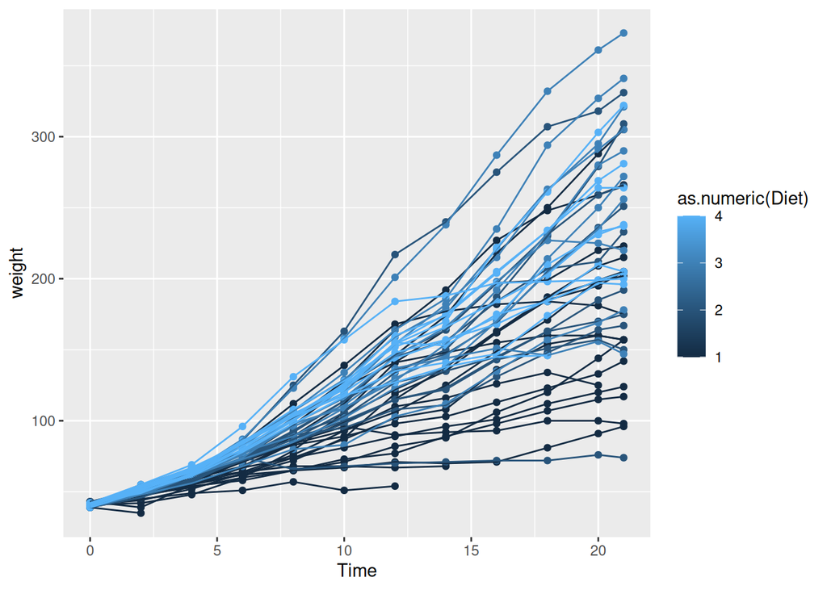

```r
ggplot(cw1, aes(x = Time, y = weight, colour = as.numeric(Diet), group = Chick)) +
  geom_point() + geom_line()
```

That makes the diets just a bit difficult to tell apart!

(The principle is that to represent a number by a colour, you have to be able to represent things like 3.5 as well as whole numbers.)

Having realized why this was happening, I then went back and put a D on the front of the diet names (so that they became D1 through D4), and then they would be guaranteed categorical when the time came. Then, everything works. (In the original data, `Diet` is stored as a `factor` that happens to have numerical levels,[^2] so everything works, but when I save it and you read it back in, the diets are read in as numbers.)

2. Rearrange the data to have a column containing all the weights and a column containing the times (in days since birth) that those weights were measured, identified by the `Chick` and the `Diet` the chick was on. Save your new dataframe.

This is a pivot-longer, but one of the difficult ones. The columns we’re going to pivot-longer have names like `weight_2` or `Time_3`; the second bit, after the underscore, is a number that’s going into a column (that I’m going to call `rep`, but you can call it whatever makes sense to you), but the *first* bit of these column names is going to become the *name* of a column, as in “a hairy one” in lecture where the variables we measured were called `y` and `z` and they needed to end up in their own columns. The columns we want to pivot-longer all have an underscore in their names, so this will do it:

```r
chick_weights %>% pivot_longer(contains("_"),
                               names_to = c(".value", "rep"),
                               names_sep = "_") -> chick_weights_long
chick_weights_long
```

| Chick | Diet | rep | weight | Time |
| --- | --- | --- | --- | --- |
| 1 | D1 | 1 | 42 | 0 |
| 1 | D1 | 2 | 51 | 2 |
| 1 | D1 | 3 | 59 | 4 |
| 1 | D1 | 4 | 64 | 6 |
| 1 | D1 | 5 | 76 | 8 |
| 1 | D1 | 6 | 93 | 10 |
| 1 | D1 | 7 | 106 | 12 |
| 1 | D1 | 8 | 125 | 14 |
| 1 | D1 | 9 | 149 | 16 |
| 1 | D1 | 10 | 171 | 18 |

[output cut: 590 more lines]

Now we have a lot of rows: 50 chicks times 12 measurements on each one, some of which are actually missing. The `rep` column has probably served its purpose (it tells you, for example, that the first chick, which was on diet D1, weighed 125 grams at its 8th measurement, which was 14 days after the chick was born).

Note that the code in these has *no* `values_to`; the values are going into the appropriate one of the new columns we’re using `.values` to make, the weights into `weight` and the times into `Time`.

This layout of the data allows for the possibility that, say, the 10th weight measurement of chick 20 was taken at a different time than the 10th weight measurement of chick 21. (In that case, `Time_10` would have different values for chicks 20 and 21). I don’t think that’s actually the case here, however, apart from some missing values, so that the original `Time_10` column has a lot of repeats.

3. Make a spaghetti plot: that is to say, plot weight against time for each chick, joining the points for the *same chick* by lines, and colouring the points and lines by diet. Hint: follow the model in the lecture notes.

The point of this question is to sort-of convince you that once you have data in the right layout, making a graph or a summary is not too hard. Plus, graphs are pretty. Use the dataframe that I called `chick_weights_long`, the one that you went to such trouble to make:

```
Warning: Removed 22 rows containing missing values or values outside the scale range
(`geom_point()`).
```

```
Warning: Removed 22 rows containing missing values or values outside the scale range
(`geom_line()`).
```

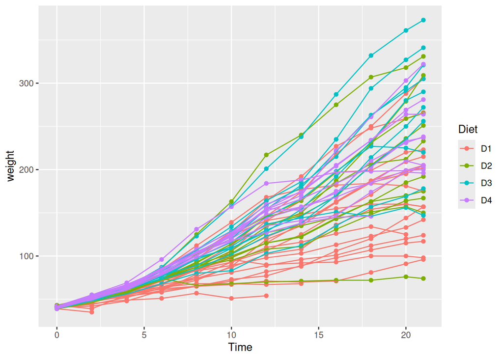

```r
ggplot(chick_weights_long, aes(x = Time, y = weight, colour = Diet, group = Chick)) +
  geom_point() + geom_line()
```

You’ll get a warning about missing values (not all the chicks were weighed at all 12 times). That can safely be ignored.

As for the code, `Time` is time, on the $x$-axis (here, you could probably also use `rep` or its equivalent in your code). `weight` goes on the $y$-axis. The diets are going to be indicated by different colours, so `colour` is `Diet`. The extra unexpected thing is the `group`, which is probably new to you. The problem with having colour as `Diet` is that without the `group =`, *all* the points of the same colour will get joined by lines, and that’s not what we want. The trick is that `group`, if we have one, *overrides* the colour, so that in this case the only points joined by a line are ones that belong to the same chick. (`Chick` is serving the same purpose as an `id` variable that uniquely identifies the individual chicks, something that was made for us here rather than our having to make it ourselves.)

All of the chicks are growing over time to some extent (as you would expect). As for the diets:

- diet D1 looks bad (most of the red traces end up at the bottom)
- diet D2 is all over the place (the green traces are sometimes at the top and sometimes lower down)
- diet D3 seems to be good (pale blue traces near the top)
- diet D4 is mostly good (purple traces middling to high).

When we come to study data like this in D29, we would expect to see a significant diet effect here, once we take care to allow for the fact that we have multiple measurements on the same chicks. Likewise, there would be a clear time effect (all the chicks are growing). We would also test for an interaction between diet and time, to see whether the time effect depends on diet (the *manner* of growth depends on the diet, not just that one diet was best all the way along).

Extra: the other graph you could make here is an “interaction plot” of the mean weights by time and diet. To kick this off, use group-by and summarize to work out the mean weights of all the combinations of `Diet` and `Time`:

```r
chick_weights_long %>%
  drop_na(Time) %>%
  group_by(Diet, Time) %>%
  summarize(mean_weight = mean(weight, na.rm = TRUE))
```

| Diet | Time | mean_weight |
| --- | --- | --- |
| D1 | 0 | 41.40000 |
| D1 | 2 | 47.25000 |
| D1 | 4 | 56.47368 |
| D1 | 6 | 66.78947 |
| D1 | 8 | 79.68421 |
| D1 | 10 | 93.05263 |
| D1 | 12 | 108.52632 |
| D1 | 14 | 123.38889 |
| D1 | 16 | 144.64706 |
| D1 | 18 | 158.94118 |

[output cut: 38 more lines]

We have to be a bit careful about missing values. There are some missing *times*, which we want nothing to do with, and there are also some missing weights observed at reasonable times, that we want to not count in the means. The first of these is accounted for by dropping rows with missing `Time`, and the second is accounted for by using `na.rm` in the calculation of the mean (to remove the missing values before the mean is calculated).

To make an interaction plot, we plot the means against time, joining the points for the same `Diet` by lines. This also makes use of `group =`:

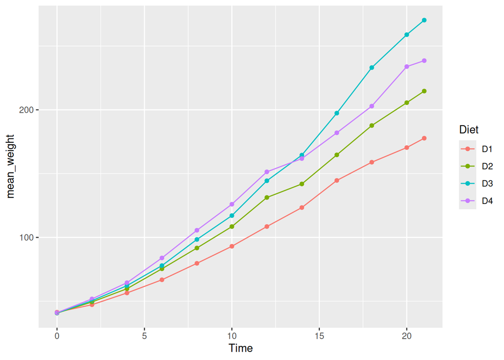

```r
chick_weights_long %>%
  drop_na(Time) %>%
  group_by(Diet, Time) %>%
  summarize(mean_weight = mean(weight, na.rm = TRUE)) %>%
  ggplot(aes(x = Time, y = mean_weight,
             colour = Diet, group = Diet)) +
  geom_point() + geom_line()
```

The thing to remember in an interaction plot is that you have both a `colour` and a `group`, and *they are the same*. Note also that you are this time making a graph *of the summary* (the means), so you pipe the dataframe you made just above *straight into* `ggplot` (or, save the summary and use *that* in `ggplot`, your choice).

If you have used one of these graphs in your second course, you might remember that what you do with it is to judge whether the coloured lines are more or less parallel (no interaction) or not (interaction). These are sort-of parallel in that they go up in more or less the same way, but Diet 3 overtakes Diet 4 on about day 14 and the chicks on Diet 3 are heavier on average from there on. If a suitable test (D29) has a significant interaction between time and diet, it will be because of that inconsistency of pattern.

## American Community Survey

The American Community Survey is a huge sample survey that addresses many aspects of American communities. The data in http://ritsokiguess.site/datafiles/acs4.txt, in aligned columns, contain estimates of the total housed population (that own or rent a place to live), the total number of renters, and the median rent, in two US states. The column called `error` contains standard errors of the estimates (obtained using methods like the ones in STAC53). The states are identified by name and number, the latter in the column `geoid`.

4. Read in and display the data.

There are only six rows and five columns, so you should see it all when you display your dataframe. The `.txt` on the end of the file should clue you in that there is something non-standard going on here; the question says “aligned columns”, so `read_table` is what you need, instead of the usual `read_csv`:

```r
library(tidyverse)
my_url <- "http://ritsokiguess.site/datafiles/acs4.txt"
acs <- read_table(my_url)
acs
```

| geoid | name | variable | estimate | error |
| --- | --- | --- | --- | --- |
| 01 | Alabama | pop_housed | 4731852 | 48312 |
| 01 | Alabama | pop_renter | 1434765 | 16736 |
| 01 | Alabama | median_rent | 747 | 3 |
| 13 | Georgia | pop_housed | 9943137 | 51307 |
| 13 | Georgia | pop_renter | 3592422 | 33385 |
| 13 | Georgia | median_rent | 927 | 3 |

That looks good.

5. Create columns containing the values in `estimate` for each of the three items in `variable`. (That is to say, you should get three new columns; the names of those new columns are the items in `variable`.) This first attempt will probably give you six rows and some missing values, which is fine for the moment (we discuss *why* there are missing values in the next question).

Run `pivot_wider` exactly as you would guess:

```r
acs %>% pivot_wider(names_from = variable, values_from = estimate)
```

| geoid | name | error | pop_housed | pop_renter | median_rent |
| --- | --- | --- | --- | --- | --- |
| 01 | Alabama | 48312 | 4731852 | NA | NA |
| 01 | Alabama | 16736 | NA | 1434765 | NA |
| 01 | Alabama | 3 | NA | NA | 747 |
| 13 | Georgia | 51307 | 9943137 | NA | NA |
| 13 | Georgia | 33385 | NA | 3592422 | NA |
| 13 | Georgia | 3 | NA | NA | 927 |

This looks weird, but it is the *correct* answer for this question. We are about to discuss why it came out this way.

6. Explain briefly why your output in the previous question came out as it did.

You are probably wondering where those missing values came from (or, why we didn’t get two rows, one for each state). We got the right columns (the values in the `estimate` column got distributed over the three new columns, which is correct). The problem is the rows. To think about what happened, let’s look back at the original data:

```r
acs
```

| geoid | name | variable | estimate | error |
| --- | --- | --- | --- | --- |
| 01 | Alabama | pop_housed | 4731852 | 48312 |
| 01 | Alabama | pop_renter | 1434765 | 16736 |
| 01 | Alabama | median_rent | 747 | 3 |
| 13 | Georgia | pop_housed | 9943137 | 51307 |
| 13 | Georgia | pop_renter | 3592422 | 33385 |
| 13 | Georgia | median_rent | 927 | 3 |

and the code that we ran above:

```r
acs %>% pivot_wider(names_from = variable, values_from = estimate)
```

Isolate that the problem is in the rows, and that what determines the row is the combination of *all* the other variables not named in the `pivot_wider`, and that the `error` values cause the problem. Or, if you like, say that if we didn’t have the `error` column, there would be only two `name`-`geoid` combinations, and we’d get the two rows we were expecting.

We as statisticians would call `name` and `geoid` “identifier variables” in that either or both of them identify the “experimental units”, states here. [Database people](https://www.databasestar.com/database-keys/) would call these two columns “keys”. Keys can be “natural” (like the name of the state), or “surrogate” (something made-up that also identifies the state like `geoid`). Keys are often used to make sure a `left_join` matches the right things: in the lecture example of nails at Canadian Tire, each type of nail had its own ID (a so-called “primary key”) so that we could look it up in the catalog to see what it actually was.

7. Using techniques learned in this course and your insight from the previous question, arrange the data to have three columns of `estimate` values whose names are the three items in `variable`, and only two rows, one for each state.

In the previous part, you discovered that the `error` column was the problem (or that the desired rearrangement has nothing to do with `error`), so you can safely remove it before doing the `pivot_wider`:

```r
acs %>%
  select(-error) %>%
  pivot_wider(names_from = variable, values_from = estimate)
```

| geoid | name | pop_housed | pop_renter | median_rent |
| --- | --- | --- | --- | --- |
| 01 | Alabama | 4731852 | 1434765 | 747 |
| 13 | Georgia | 9943137 | 3592422 | 927 |

and this is now what we wanted. There is a general principle here: when you are about to do a pivot-wider, you may have columns that are not of interest to you, and also play no role in determining what row things should go in. You should remove those columns before you do the pivot-wider.

Applying the rationale of the previous part: there are now only two columns not named in the pivot-wider, `geoid` and `name`, and there are only two combinations of those, because each ID goes with only one state.

Alternative approach: you might have recognized earlier that `error` was going to cause a problem, and removed it first (so that your answers to the two `pivot_wider` parts are the same). This is fine, as long as you have an explanation somewhere that makes it clear you understand why it is that the `error` column is the problematic one. “We don’t use `error` in this question” is not enough because the point is to understand *why* it is causing (or would cause) `pivot_wider` to give an unexpected answer.

Extra 1: The data came from [here](https://dcl-wrangle.stanford.edu/pivot-advanced.html#wider-1). There, they suggest using `id_cols` to specify which columns identify rows. This site was one of the first few hits for me, so it is not difficult to search for. However, `id_cols` is not something we did in lecture, so there was no credit for it here (when this was an assignment problem; minimal credit if you cited your source). If you are interested anyway, it goes like this:

```r
acs %>%
  pivot_wider(names_from = variable, values_from = estimate,
              id_cols = c(geoid, name))
```

| geoid | name | pop_housed | pop_renter | median_rent |
| --- | --- | --- | --- | --- |
| 01 | Alabama | 4731852 | 1434765 | 747 |
| 13 | Georgia | 9943137 | 3592422 | 927 |

You can put just one of `geoid` and `name` in the `id_cols`, but then only the one you put there will show up in the result. (You can also say `id_cols = -error` to achieve the same thing as I just got: “the `error` column does *not* identify the individual states”.)

This does the same thing as we did by hand: it removes the column `error` that contains neither column names nor column values nor row identifiers, and then pivots wider. (The logic is “use *only* the column(s) named to decide which row each data value goes in”.)

When this was an assignment problem (worth three points): three points if you remove the `error` column and re-do your pivot-wider. No points if you use `id_cols` without saying where it came from, and one if you cite your source in a way that can be checked.[^3] The lecture material has everything you need to solve this problem. Why are you in this course if you don’t want to use it?

Extra 2: if you want to keep the `error` values and have them go along with the estimate values, you can do something like this:

```r
acs %>%
  pivot_wider(names_from = variable, values_from = c(estimate, error))
```

| geoid | name | estimate_pop_housed | estimate_pop_renter | estimate_median_rent | error_pop_housed | error_pop_renter | error_median_rent |
| --- | --- | --- | --- | --- | --- | --- | --- |
| 01 | Alabama | 4731852 | 1434765 | 747 | 48312 | 16736 | 3 |
| 13 | Georgia | 9943137 | 3592422 | 927 | 51307 | 33385 | 3 |

There are now a lot of columns. `pivot_wider` has created two sets of value columns. The ones beginning with `estimate` are the same ones we had before, but there are also columns with names beginning `error` that are the standard errors for that variable in that state. The `pivot_wider` now mentions all the other variables apart from the ones that identify states, so we correctly get two rows, one for each state. When there is more than one variable in `values_from`, `pivot_wider` glues the name of each original variable onto the front of the names of the new columns, so that you can tell which is which.

If it were not for the fact that the column names already had underscores in them, you would be able to take this dataframe and pivot it longer to get the original dataframe back that you read from the file. To illustrate, separating things now by a *colon* to keep things straight:

```r
acs %>%
  pivot_wider(names_from = variable,
              values_from = c(estimate, error),
              names_sep = ":")
```

| geoid | name | estimate:pop_housed | estimate:pop_renter | estimate:median_rent | error:pop_housed | error:pop_renter | error:median_rent |
| --- | --- | --- | --- | --- | --- | --- | --- |
| 01 | Alabama | 4731852 | 1434765 | 747 | 48312 | 16736 | 3 |
| 13 | Georgia | 9943137 | 3592422 | 927 | 51307 | 33385 | 3 |

The values in the original column `variable` are separated by underscores; this time I used a colon to separate the original variables `estimate` and `error` from what they are estimates and errors of. So now I should be able to `pivot_longer`, allowing for the fact that the column names encode two things, one of which should make new column names:

```r
acs %>%
  pivot_wider(names_from = variable,
              values_from = c(estimate, error),
              names_sep = ":") %>%
  pivot_longer(starts_with("e"),
               names_to = c(".value", "variable"),
               names_sep = ":")
```

| geoid | name | variable | estimate | error |
| --- | --- | --- | --- | --- |
| 01 | Alabama | pop_housed | 4731852 | 48312 |
| 01 | Alabama | pop_renter | 1434765 | 16736 |
| 01 | Alabama | median_rent | 747 | 3 |
| 13 | Georgia | pop_housed | 9943137 | 51307 |
| 13 | Georgia | pop_renter | 3592422 | 33385 |
| 13 | Georgia | median_rent | 927 | 3 |

and we are indeed back where we started: this funky[^4] `pivot_longer` is the inverse of the funky `pivot_wider` that preceded it.

## Footnotes

[^1]: This seems weird, but it is actually the right thing to do, if you stop and think about it.
[^2]: If you remember the problem with houses that had 3 or 4 bedrooms: we had to turn the number of bedrooms into a `factor` to get a boxplot to work.
[^3]: Chatgpt and the like, you are reminded, are *not* reliable sources.
[^4]: See [this dictionary](https://www.merriam-webster.com/dictionary/funky): the original meaning was “smelly”, but then it came to be applied to music that resembled African-American blues or gospel, particularly in rhythm, and then to anything unconventional, which is my meaning here.